# Red Wine Quality Analysis by Mehlam Murtaza

# Introduction

The purpose of this project is to **determine the quality of wine** based of their chemical properties using univaiate, bivariate and multivariate exploratory data analysis techniques. The analysis will begin from a broad univariate perspective where we can gage our data from a basic perspective then using those assumptions and intuition we will then begin to drill down using the bi and multi variate techniques.

# Univariate Analysis

This first section is treated as a preliminary exploration of the data where we will begin to make our assumptions through summaries and basic statistical techniques:

```
##  [1] "X"                    "fixed.acidity"        "volatile.acidity"
##  [4] "citric.acid"          "residual.sugar"       "chlorides"
##  [7] "free.sulfur.dioxide"  "total.sulfur.dioxide" "density"
## [10] "pH"                   "sulphates"            "alcohol"
## [13] "quality"
```

```
## 'data.frame':    1599 obs. of  13 variables:
##  $ X                   : int  1 2 3 4 5 6 7 8 9 10 ...
##  $ fixed.acidity       : num  7.4 7.8 7.8 11.2 7.4 7.4 7.9 7.3 7.8 7.5 ...
##  $ volatile.acidity    : num  0.7 0.88 0.76 0.28 0.7 0.66 0.6 0.65 0.58 0.5 ...
##  $ citric.acid         : num  0 0 0.04 0.56 0 0 0.06 0 0.02 0.36 ...
##  $ residual.sugar      : num  1.9 2.6 2.3 1.9 1.9 1.8 1.6 1.2 2 6.1 ...
##  $ chlorides           : num  0.076 0.098 0.092 0.075 0.076 0.075 0.069 0.065 0.073 0.071 ...
##  $ free.sulfur.dioxide : num  11 25 15 17 11 13 15 15 9 17 ...
##  $ total.sulfur.dioxide: num  34 67 54 60 34 40 59 21 18 102 ...
##  $ density             : num  0.998 0.997 0.997 0.998 0.998 ...
##  $ pH                  : num  3.51 3.2 3.26 3.16 3.51 3.51 3.3 3.39 3.36 3.35 ...
##  $ sulphates           : num  0.56 0.68 0.65 0.58 0.56 0.56 0.46 0.47 0.57 0.8 ...
##  $ alcohol             : num  9.4 9.8 9.8 9.8 9.4 9.4 9.4 10 9.5 10.5 ...
##  $ quality             : int  5 5 5 6 5 5 5 7 7 5 ...
```

*Interpretation:* A breakdown of the strucuture of our data and the actual data within it. There are 1599 rows of wine data with 13 rows of donating the different aspects such as the chemical content (pH, density alcohol etc..) and quality (rated 1-10)

```
##        X          fixed.acidity   volatile.acidity  citric.acid
##  Min.   :   1.0   Min.   : 4.60   Min.   :0.1200   Min.   :0.000
##  1st Qu.: 400.5   1st Qu.: 7.10   1st Qu.:0.3900   1st Qu.:0.090
##  Median : 800.0   Median : 7.90   Median :0.5200   Median :0.260
##  Mean   : 800.0   Mean   : 8.32   Mean   :0.5278   Mean   :0.271
##  3rd Qu.:1199.5   3rd Qu.: 9.20   3rd Qu.:0.6400   3rd Qu.:0.420
##  Max.   :1599.0   Max.   :15.90   Max.   :1.5800   Max.   :1.000
##  residual.sugar     chlorides       free.sulfur.dioxide
##  Min.   : 0.900   Min.   :0.01200   Min.   : 1.00
##  1st Qu.: 1.900   1st Qu.:0.07000   1st Qu.: 7.00
##  Median : 2.200   Median :0.07900   Median :14.00
##  Mean   : 2.539   Mean   :0.08747   Mean   :15.87
##  3rd Qu.: 2.600   3rd Qu.:0.09000   3rd Qu.:21.00
##  Max.   :15.500   Max.   :0.61100   Max.   :72.00
##  total.sulfur.dioxide    density             pH          sulphates
##  Min.   :  6.00       Min.   :0.9901   Min.   :2.740   Min.   :0.3300
##  1st Qu.: 22.00       1st Qu.:0.9956   1st Qu.:3.210   1st Qu.:0.5500
##  Median : 38.00       Median :0.9968   Median :3.310   Median :0.6200
##  Mean   : 46.47       Mean   :0.9967   Mean   :3.311   Mean   :0.6581
##  3rd Qu.: 62.00       3rd Qu.:0.9978   3rd Qu.:3.400   3rd Qu.:0.7300
##  Max.   :289.00       Max.   :1.0037   Max.   :4.010   Max.   :2.0000
##     alcohol         quality
##  Min.   : 8.40   Min.   :3.000
##  1st Qu.: 9.50   1st Qu.:5.000
##  Median :10.20   Median :6.000
##  Mean   :10.42   Mean   :5.636
##  3rd Qu.:11.10   3rd Qu.:6.000
##  Max.   :14.90   Max.   :8.000
```

*Interpretation:* There are a few points of interest with this summary:

1. The quality of wine ranges from a minimum of 3 to a max of 8 and median of 6. Its interesting that there are no wines in a 0 or 10 extreme.
2. There is a high range for fixed.acidity ranging from 4.6 to 15.9
3. residual.sugar is also quite varied ranging from 0.9 to 15.5
4. the free.sulfur.dioxide and total.sulfar.dioxide also follow the high variability trend as well.
5. The pH, sulphates and alcohol is quite consistent showing much smaller rangers in their respective fields.

## Plotting the Elements

### Quality

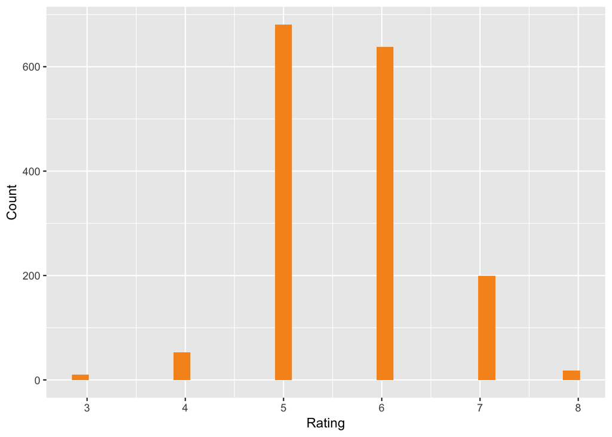

*Interpretation:* It seems that the quality (the main feature of our dataset) of the red wine has a normal distibution with the majority of wines being rated between 5 and 6.

### Univariate Plots of the chemical elements

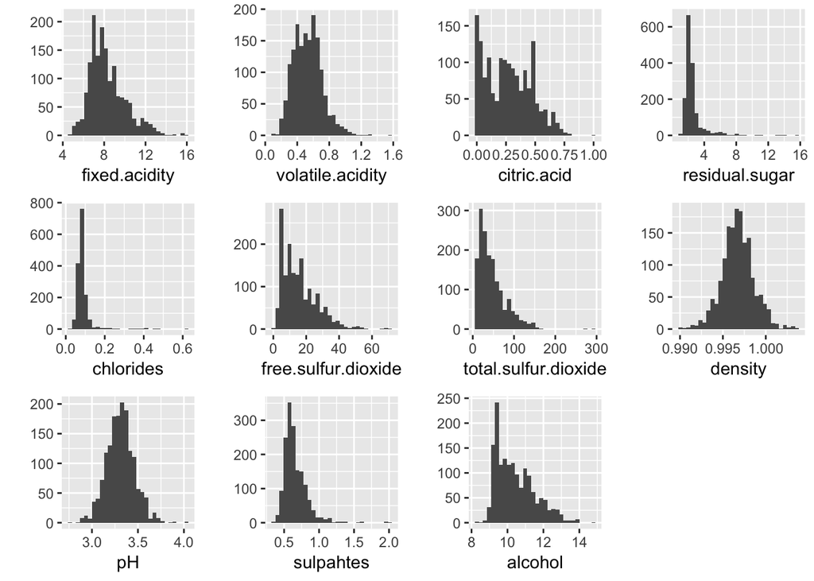

*Interpretation:* It appears that we have several long tails present in the data within fixed.acidity,volatile.acidity,free.sulfur.dioxide,total.sulfur.dioxide.sulphates and alcohol. It is also interesting to note why citric acid has such a large zero count, this was also reflected in the summary section of the univariate analysis.

#### Lets dig deeper into the anomalies we found:

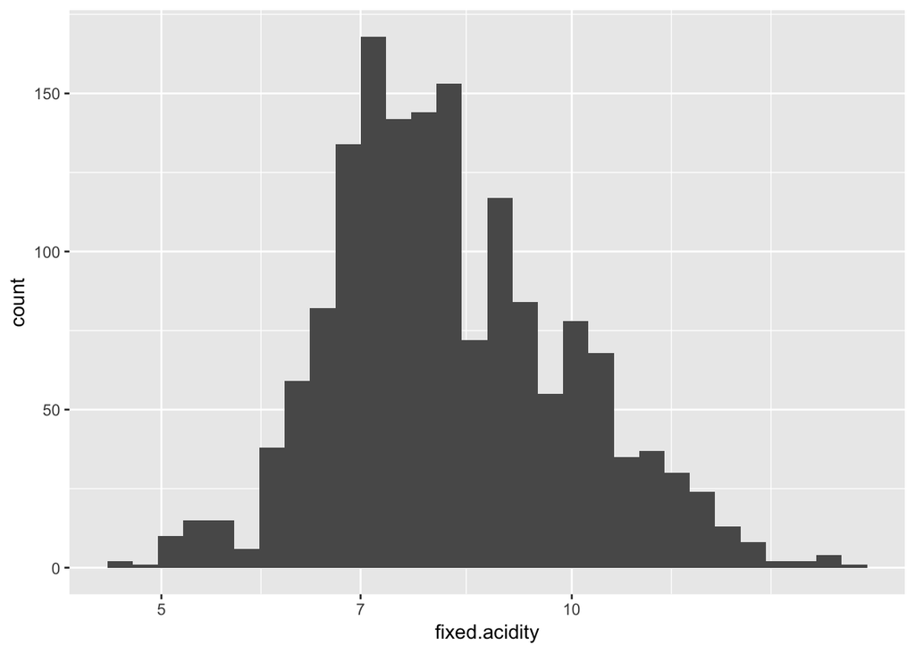

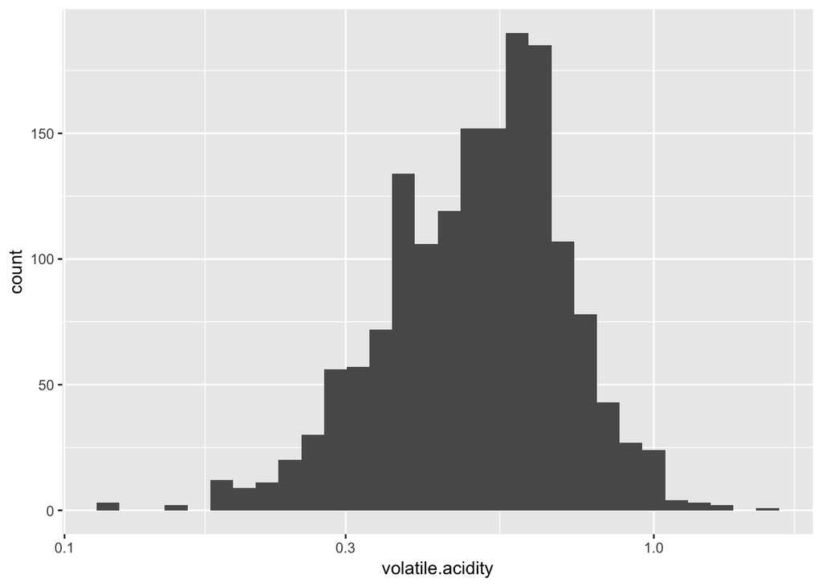

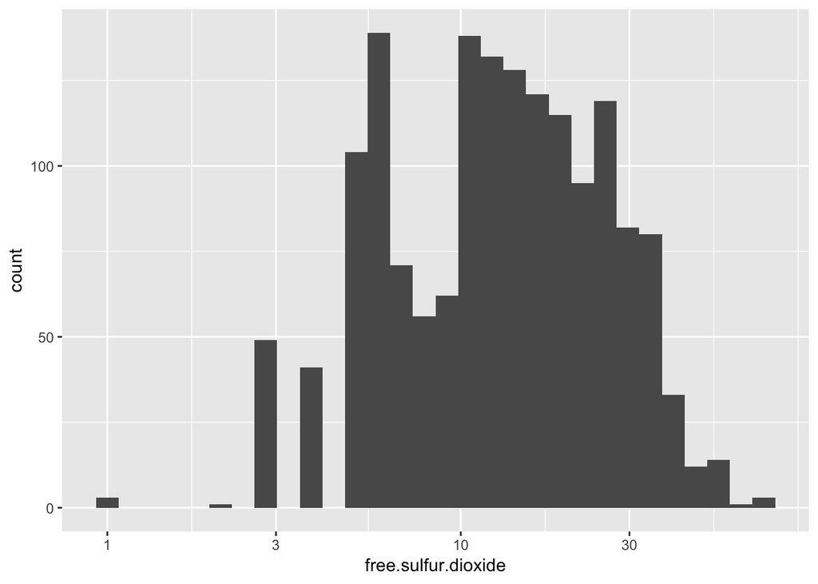

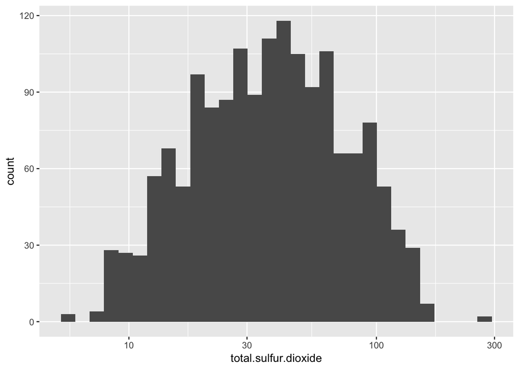

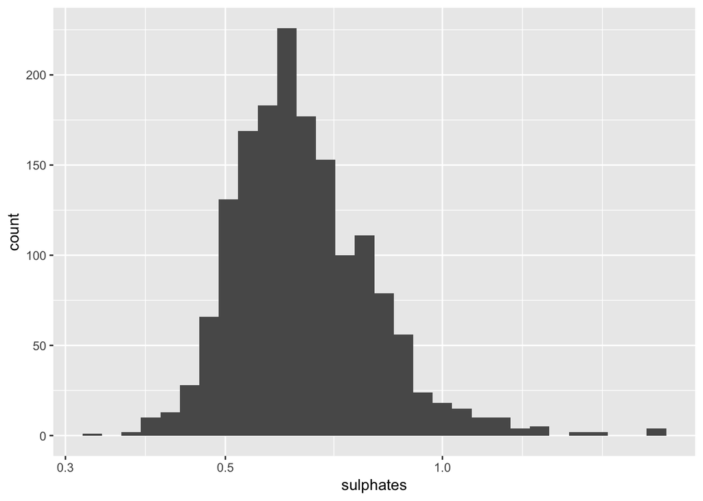

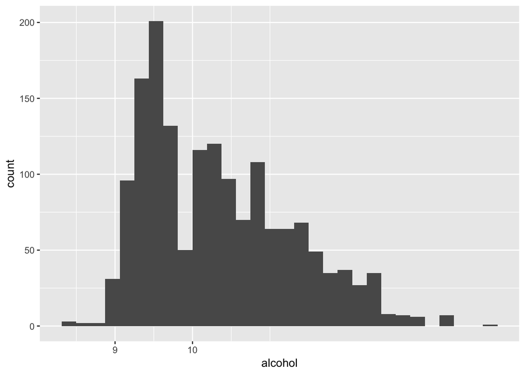

*Interpretation:* We can now see that the data is mostly normally distributed with a few outliers.

#### Citric Acid zero count

```
## [1] 132
```

*Interpretation:* There are 132 observations where citric acid is equal to zero.

## Reflection

OF the 1599 observations of the dataset, it seems that the quality column will be the main feature of our analysis and the accompanying physicochemical columns will be important for substantiating any answers we maybe looking for. For the upcoming bivariate analysis I believe it would be useful to group the quality column into 3 groups to better segment our analysis.

# Bivariate Analysis

```
##    poor average    good
##      63    1319     217
```

Now that we have created the seperate levels, let graph our new variable

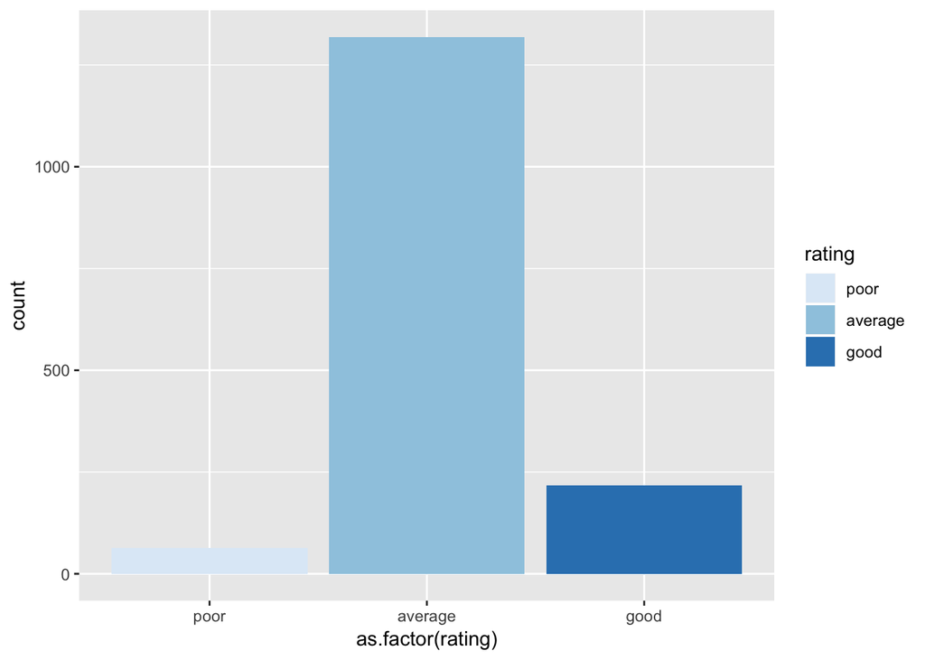

```r
ggplot(data = redwine, aes(x = as.factor(rating), fill = rating)) +
  geom_bar() +
  scale_fill_brewer(type = 'seq', palette = 1)
```

*Interpretation:* We can see that there is a normal distribution of our data.

## Ratings and Elements

Now let us compare the ratings with the various elements in graphical and statistical views

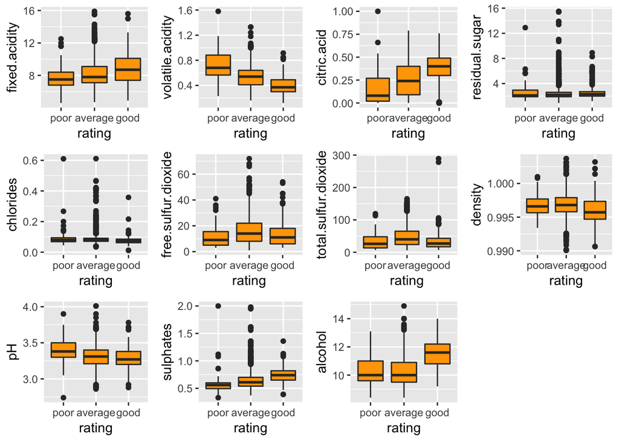

*Interpretation:* From the output there seem to be some interesting trends we can observe such as wines with good ratings have greater leveles on citric acid, sulphate and alcohol. average rated wines have higher levels of free.sulphar.dioxide, total.sulphar.dioxide and density. poor wins have greater levels of volatile.acidity and Ph.

Based on these observations lets find more correlations with ratings and the various elements

```
##        fixed.acidity     volatile.acidity          citric.acid
##           0.12405165          -0.39055778           0.22637251
##       residual.sugar            chlorides  free.sulfur.dioxide
##           0.01373164          -0.12890656          -0.05065606
## total.sulfur.dioxide              density                   pH
##          -0.18510029          -0.17491923          -0.05773139
##            sulphates              alcohol
##           0.25139708           0.47616632
```

```
## fixed.acidity   citric.acid     sulphates       alcohol
##     8.8470046     0.3764977     0.7434562    11.5180492
```

## *Relflection*

# Multivariate Analysis

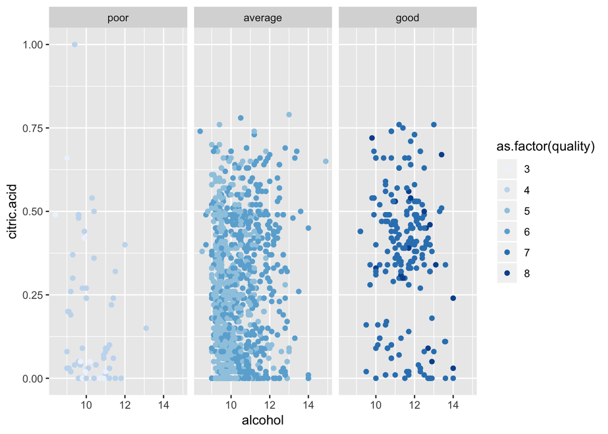

```r
#Plotting some variables which I believe would be interesting to view

ggplot(data = redwine, aes(alcohol, citric.acid, color = as.factor(quality))) +
  geom_point() +
  facet_wrap(~rating) +
  xlab('alcohol') +
  ylab('citric.acid') +
  scale_color_brewer(type = 'seq', palette = 1)
```

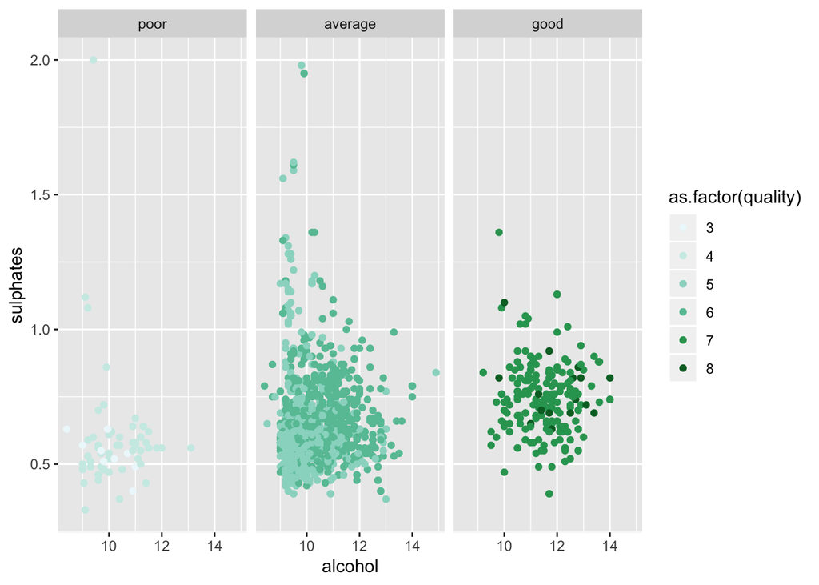

```r
ggplot(data = redwine, aes(alcohol, sulphates, color = as.factor(quality))) +
  geom_point() +
  facet_wrap(~rating) +
  xlab('alcohol') +
  ylab('sulphates') +
  scale_color_brewer(type = 'seq', palette = 2)
```

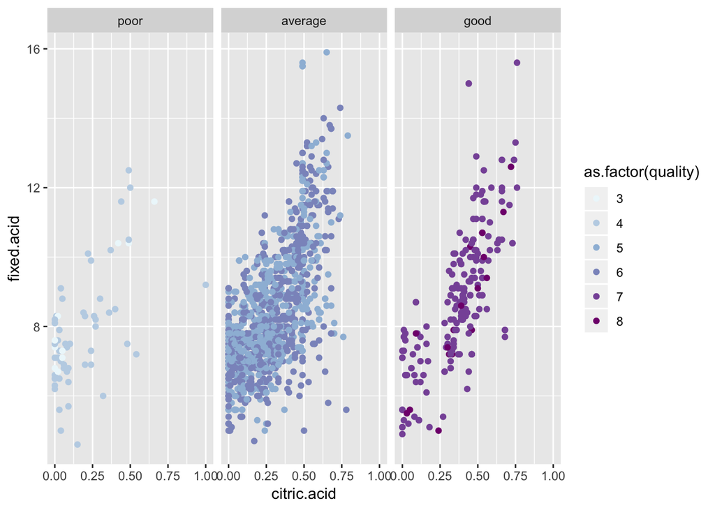

```r
ggplot(data = redwine, aes(citric.acid, fixed.acidity, color = as.factor(quality))) +
  geom_point() +
  facet_wrap(~rating) +
  xlab('citric.acid') +
  ylab('fixed.acid')  +
  scale_color_brewer(type = 'seq', palette = 3)
```

*Interpretation:* It seems that better wines have high levels of citric acid, sulphates and alcohol.

## This now concludes our analysis of the variables in regards to quality.

# Final Plots and Summary

### Plot One

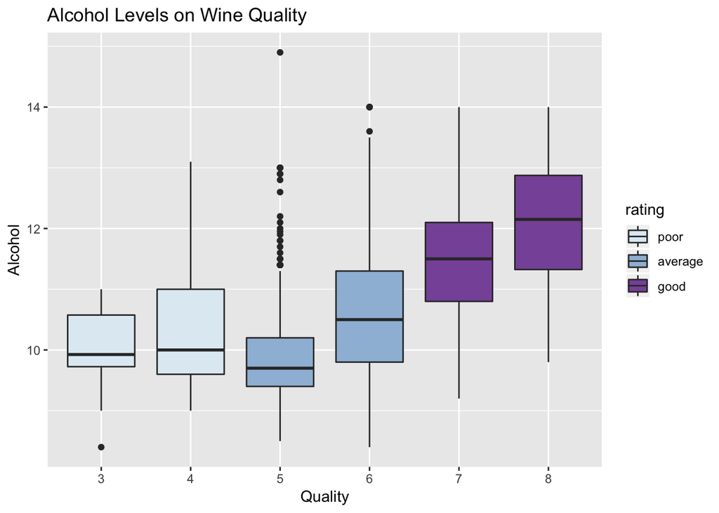

### Description One

It has become clear through our analysis that higher levels of alcohol reflect greater levels of quality.

### Plot Two

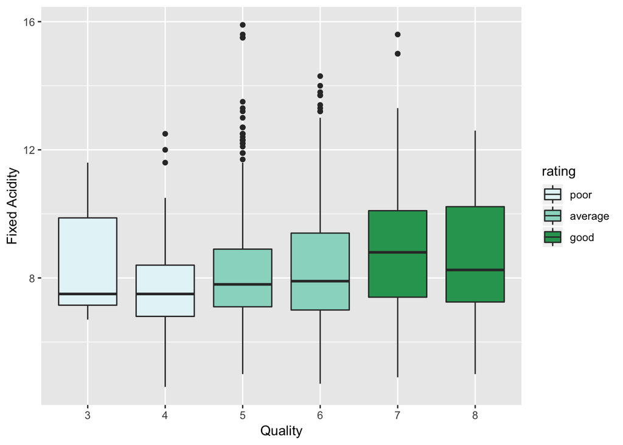

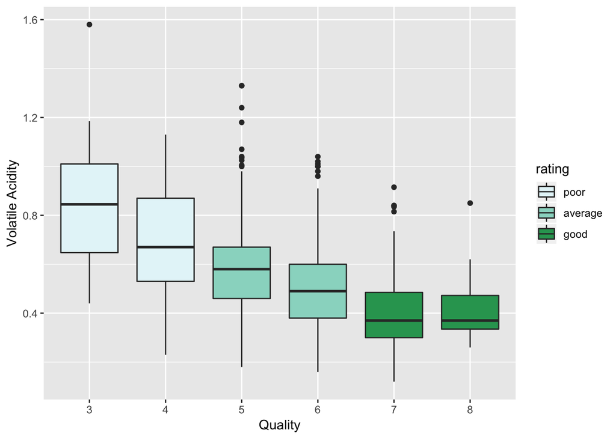

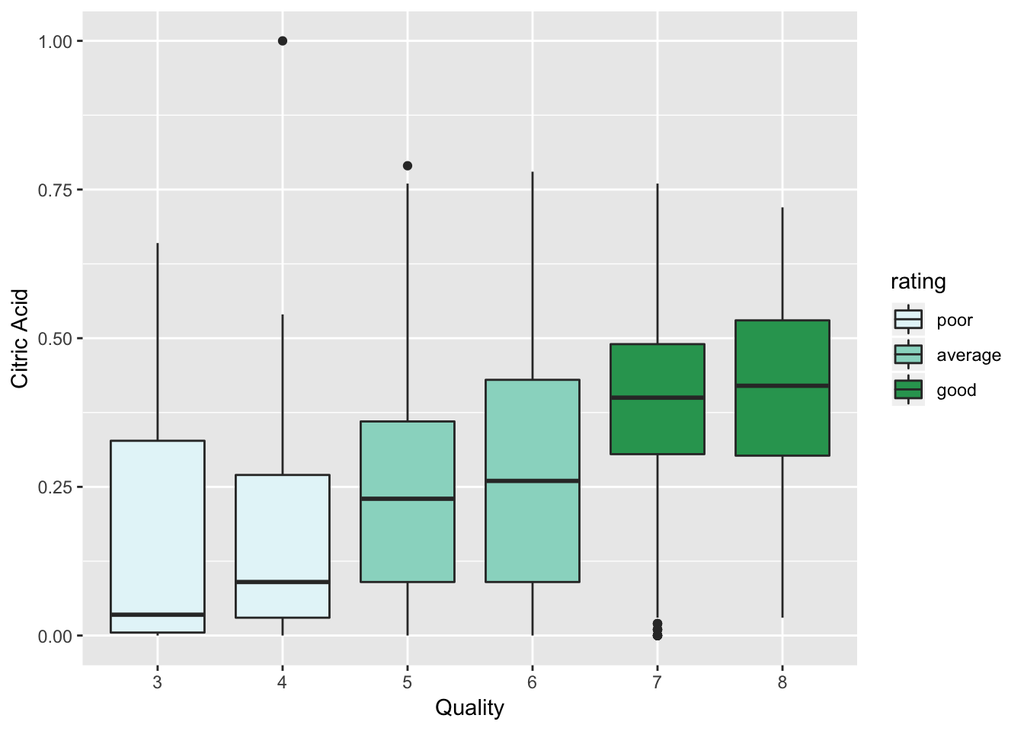

### Description Two

Similar to Alcohol, we can also see that higher levels of acidity (- volatile acidity) lead to higher wine quality rating

### Plot Three

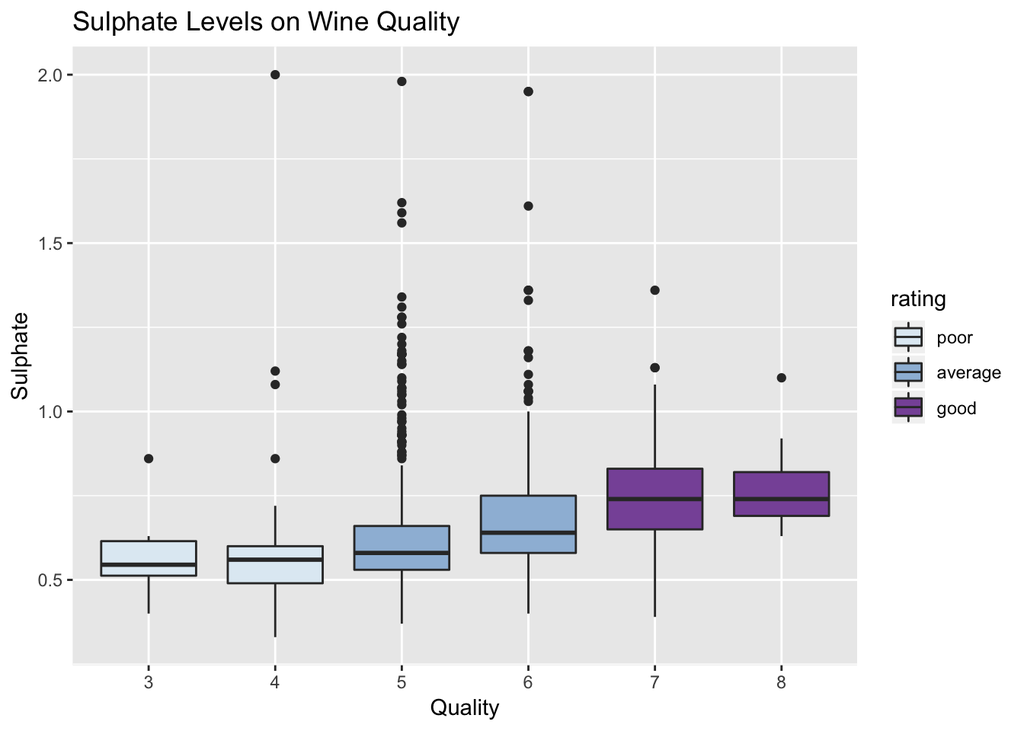

### Description Three

Though not as distinctive as the previous two results, we can see that the higher the sulphate contente, the higher the wine quality as well.

## *Reflection*

This concludes my EDA on the levels of wine quality inconjunction to the various chemical elements that compose of wines. If there were any shortcomings it would be my personal knowledge in the wine field as well as the size of the dataset itself. perhaps with a large dataset we would see the trends uncovered in this exploration be more enhanced or even completely change!